# Correlation and Dependence

Fred Viole

12/30/2020

# 1 Packages

Step 1 is to load all required packages. `NNS v(5.7)` is available on GitHub.

```r
# Load packages
require(devtools); install_github('OVVO-Financial/NNS', ref = "NNS-Beta-Version")
library(NNS)
library(mvtnorm)
library(ggplot2)
library(ggpubr)
```

# 2 Generate Functions and Data

```r
# Functions
MyPlot <- function(xy, xlim = c(-4, 4), ylim = c(-4, 4), eps = 1e-15,
                   metric = c("cor", "NNS")) {
  metric <- metric[1]

  df <- as.data.frame(xy)
  names(df) <- c("x", "y")


  if (metric == "cor") {

    value <- round(cor(xy[,1], xy[,2]), 1)

    if (sd(xy[,2]) < eps) {
      title <- paste0("cor = NA") # corr. coeff. is undefined

    } else {
      title <- paste0("cor = ", value)
    }

    subtitle <- NULL

  } else if(all(unlist(strsplit("NNS",split=""))%in%unlist(strsplit(metric,split="")))) {
      if(metric == "NNSxy"){
          value <- round(NNS.dep(xy[,1], xy[,2], asym = TRUE)$Dependence, 1)
          title <- bquote("NNS"[X%->%Y] * " = " * .(value))
      } else if(metric == "NNSyx"){
          value <- round(NNS.dep(xy[,2], xy[,1], asym = TRUE)$Dependence, 1)
          title <- bquote("NNS"[Y%->%X] * " = " * .(value))
      } else if(metric == "NNS"){
          value <- round(NNS.dep(xy[,1], xy[,2], asym = FALSE)$Dependence, 1)
          title <- paste0("NNS dep = ", value)
      } else if(metric == "NNScor"){
          value <- round(NNS.dep(xy[,1], xy[,2])$Correlation, 1)
          title <- paste0("NNS cor = ", value)
      }

  } else if(metric == "gc"){
      value <- depMeas(xy[,1],xy[,2])
      title <- paste0("gc = ", round(value, 4))
  }

  subtitle <- NULL

  ggplot(df, aes(x, y)) +
    geom_point( color = "darkblue", size = 0.2 ) +
    xlim(xlim) +
    ylim(ylim) +
    labs(title = title,
         subtitle = subtitle) +
    theme_void() +
    theme( plot.title = element_text(size = 10, hjust = .5) )
}

MvNormal <- function(n = 1000, cor = 0.8, metric = c("cor", "ppsxy", "ppsyx", "NNS")) {
  metric <- metric[1]

  res <- list()
  j <- 0

  for (i in cor) {
    sd <- matrix(c(1, i, i, 1), ncol = 2)
    x <- rmvnorm(n, c(0, 0), sd)
    j <- j + 1
    name <- paste0("p", j)
    res[[name]] <- MyPlot(x, metric = metric)
  }

  return(res)
}

rotation <- function(t, X) return(X %*% matrix(c(cos(t), sin(t), -sin(t), cos(t)), ncol = 2))

RotNormal <- function(n = 1000, t = pi/2, metric = c("cor", "NNS")) {
  metric <- metric[1]

  sd <- matrix(c(1, 1, 1, 1), ncol = 2)
  x <- rmvnorm(n, c(0, 0), sd)

  res <- list()
  j <- 0

  for (i in t) {
    j <- j + 1
    name <- paste0("p", j)
    res[[name]] <- MyPlot(rotation(i, x), metric = metric)
  }

  return(res)
}

Others <- function(n = 1000, metric = c("cor", "NNS")) {
  metric <- metric[1]

  res <- list()

  x <- runif(n, -1, 1)
  y <- 4 * (x^2 - 1/2)^2 + runif(n, -1, 1)/3
  res[["p1"]] <- MyPlot(cbind(x,y), xlim = c(-1, 1), ylim = c(-1/3, 1+1/3), metric = metric)

  y <- runif(n, -1, 1)
  xy <- rotation(-pi/8, cbind(x,y))
  lim <- sqrt(2+sqrt(2)) / sqrt(2)
  res[["p2"]] <- MyPlot(xy, xlim = c(-lim, lim), ylim = c(-lim, lim), metric = metric)

  xy <- rotation(-pi/8, xy)
  res[["p3"]] <- MyPlot(xy, xlim = c(-sqrt(2), sqrt(2)), ylim = c(-sqrt(2), sqrt(2)), metric = metric)

  y <- 2*x^2 + runif(n, -1, 1)
  res[["p4"]] <- MyPlot(cbind(x,y), xlim = c(-1, 1), ylim = c(-1, 3), metric = metric)

  y <- (x^2 + runif(n, 0, 1/2)) * sample(seq(-1, 1, 2), n, replace = TRUE)
  res[["p5"]] <- MyPlot(cbind(x,y), xlim = c(-1.5, 1.5), ylim = c(-1.5, 1.5), metric = metric)

  y <- cos(x*pi) + rnorm(n, 0, 1/8)
  x <- sin(x*pi) + rnorm(n, 0, 1/8)
  res[["p6"]] <- MyPlot(cbind(x,y), xlim = c(-1.5, 1.5), ylim = c(-1.5, 1.5), metric = metric)

  xy1 <- rmvnorm(n/4, c( 3,  3))
  xy2 <- rmvnorm(n/4, c(-3,  3))
  xy3 <- rmvnorm(n/4, c(-3, -3))
  xy4 <- rmvnorm(n/4, c( 3, -3))
  res[["p7"]] <- MyPlot(rbind(xy1, xy2, xy3, xy4), xlim = c(-3-4, 3+4), ylim = c(-3-4, 3+4), metric = metric)

  return(res)
}

output <- function( metric = c("cor", "NNS") ) {
  metric <- metric[1]

  plots1 <- MvNormal( n = 800, cor = c(1.0, 0.8, 0.4, 0.0, -0.4, -0.8, -1.0), metric = metric );
  plots2 <- RotNormal(200, c(0, pi/12, pi/6, pi/4, pi/2-pi/6, pi/2-pi/12, pi/2), metric = metric);
  plots3 <- Others(800, metric = metric)

  ggarrange(
    plots1$p1, plots1$p2, plots1$p3, plots1$p4, plots1$p5, plots1$p6, plots1$p7,
    plots2$p1, plots2$p2, plots2$p3, plots2$p4, plots2$p5, plots2$p6, plots2$p7,
    plots3$p1, plots3$p2, plots3$p3, plots3$p4, plots3$p5, plots3$p6, plots3$p7,

    ncol = 7, nrow = 3
  )
}
```

# 3 Plots

## 3.1 Pearson Correlation

Of particular note is the final row of images, whereby there is clearly a dependence between variables that cannot be captured through this linear measure.

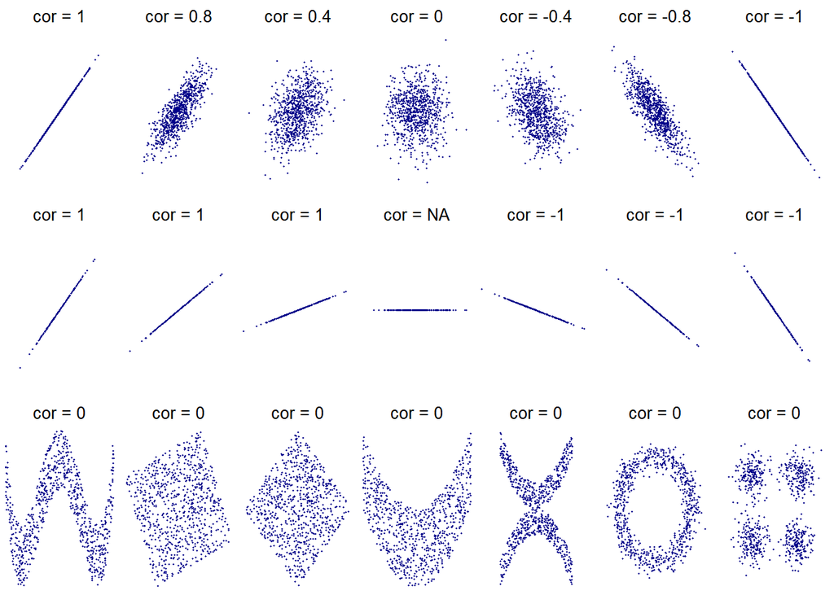

```r
output(metric = "cor")
```

## 3.2 NNS dependence

`NNS` offers insights to the strength of dependence between variables when linearity fails. Below is a general example of a sine wave and its corresponding correlation and dependence values:

```r
x <- seq(.01, 3*pi, pi/100)
y <- sin(x)

NNS.dep(x,y)
```

```
## $Correlation
## [1] -0.003666096
##
## $Dependence
## [1] 0.9811196
```

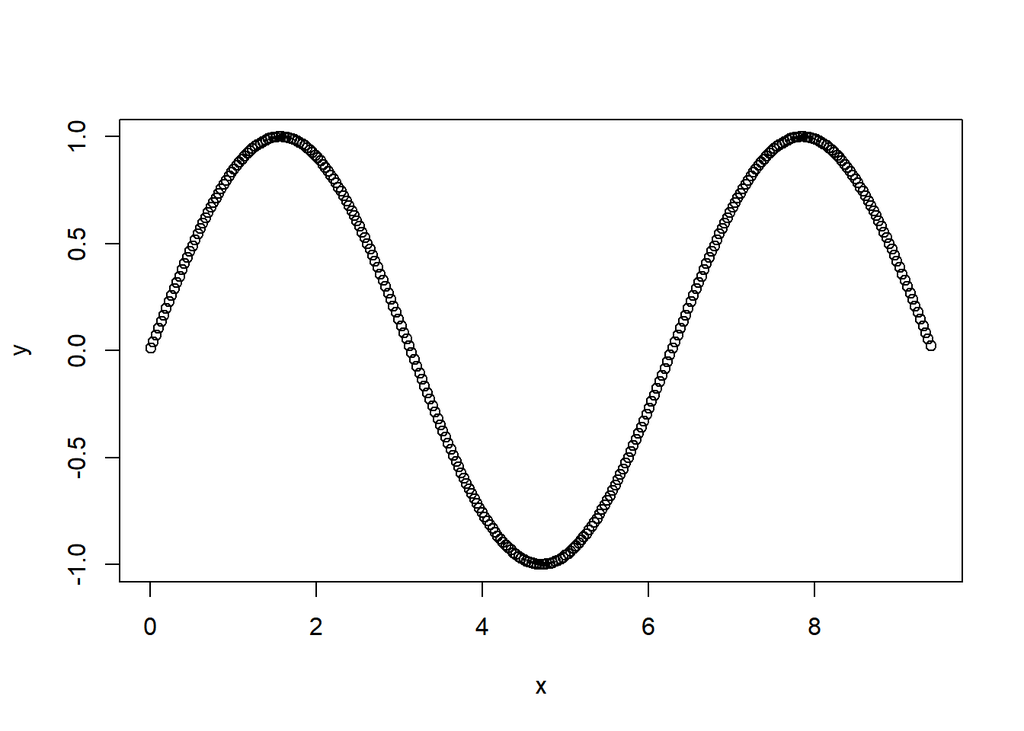

```r
plot(x,y)
```

Now back to the original examples:

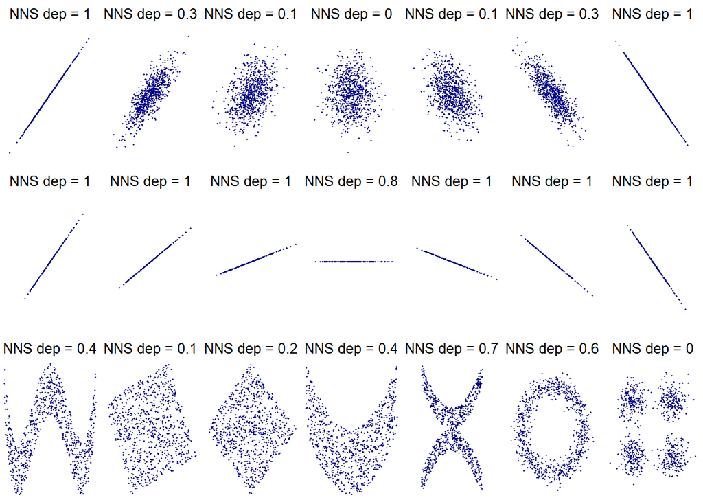

```r
output(metric = "NNS")
```

## 3.3 Asymmetrical NNS dependence

`NNS` offers the ability to view asymmetrical dependence measures, by using the argument `asym = TRUE` to evaluate `X->Y` correlation and dependence structures. Note the difference of asymmetry in the following matrices when performed on the dataset.

```r
NNS.dep(iris, asym = FALSE)
```

```
## $Correlation
##              Sepal.Length Sepal.Width Petal.Length Petal.Width    Species
## Sepal.Length    1.0000000   0.1959000    0.2466481   0.1480629  0.7980781
## Sepal.Width     0.1959000   1.0000000    0.1477749   0.2308152 -0.4402896
## Petal.Length    0.2466481   0.1477749    1.0000000   0.2704558  0.9354305
## Petal.Width     0.1480629   0.2308152    0.2704558   1.0000000  0.9381792
## Species         0.7980781  -0.4402896    0.9354305   0.9381792  1.0000000
##
## $Dependence
##              Sepal.Length Sepal.Width Petal.Length Petal.Width   Species
## Sepal.Length    1.0000000   0.4545707    0.5216778   0.4716064 0.7980781
## Sepal.Width     0.4545707   1.0000000    0.4817219   0.4987360 0.4402896
## Petal.Length    0.5216778   0.4817219    1.0000000   0.5423818 0.9354305
## Petal.Width     0.4716064   0.4987360    0.5423818   1.0000000 0.9381792
## Species         0.7980781   0.4402896    0.9354305   0.9381792 1.0000000
```

```r
NNS.dep(iris, asym = TRUE)
```

```
## $Correlation
##              Sepal.Length Sepal.Width Petal.Length Petal.Width    Species
## Sepal.Length    1.0000000  0.04147665    0.3518427   0.2180822  0.7980781
## Sepal.Width     0.1656569  1.00000000    0.2194986   0.3407249 -0.4402896
## Petal.Length    0.2577601  0.02970281    1.0000000   0.3198100  0.9354305
## Petal.Width     0.1184715  0.14913811    0.3031992   1.0000000  0.9381792
## Species         0.7980781 -0.44028958    0.9354305   0.9381792  1.0000000
##
## $Dependence
##              Sepal.Length Sepal.Width Petal.Length Petal.Width   Species
## Sepal.Length    1.0000000   0.3424474    0.4647213   0.3992455 0.7980781
## Sepal.Width     0.4135840   1.0000000    0.4441067   0.5011180 0.4402896
## Petal.Length    0.5047947   0.4362511    1.0000000   0.5368431 0.9354305
## Petal.Width     0.4475287   0.4969260    0.5276431   1.0000000 0.9381792
## Species         0.7980781   0.4402896    0.9354305   0.9381792 1.0000000
```

### 3.3.1 NNS dependence `[X -> Y]`

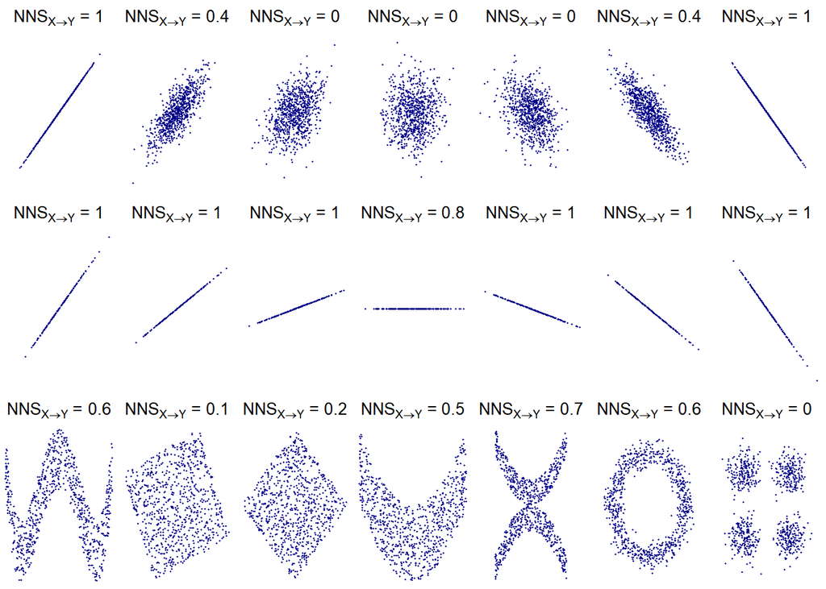

```r
output(metric = "NNSxy")
```

### 3.3.2 NNS dependence `[Y -> X]`

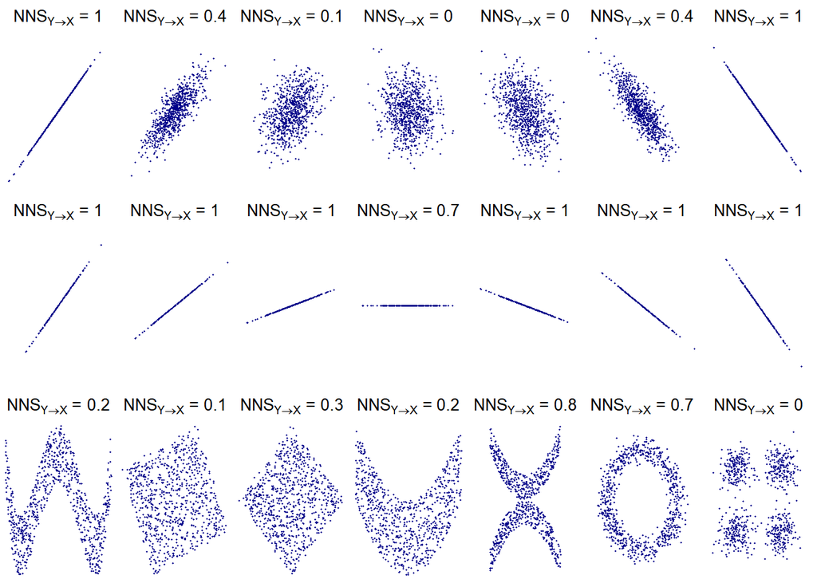

```r
output(metric = "NNSyx")
```

## 3.4 Correlation

Of course it is possible to have 0 correlation with perfect dependence between variables, and `NNS` is able to capture this dynamic through both of its measures for correlation and dependence.

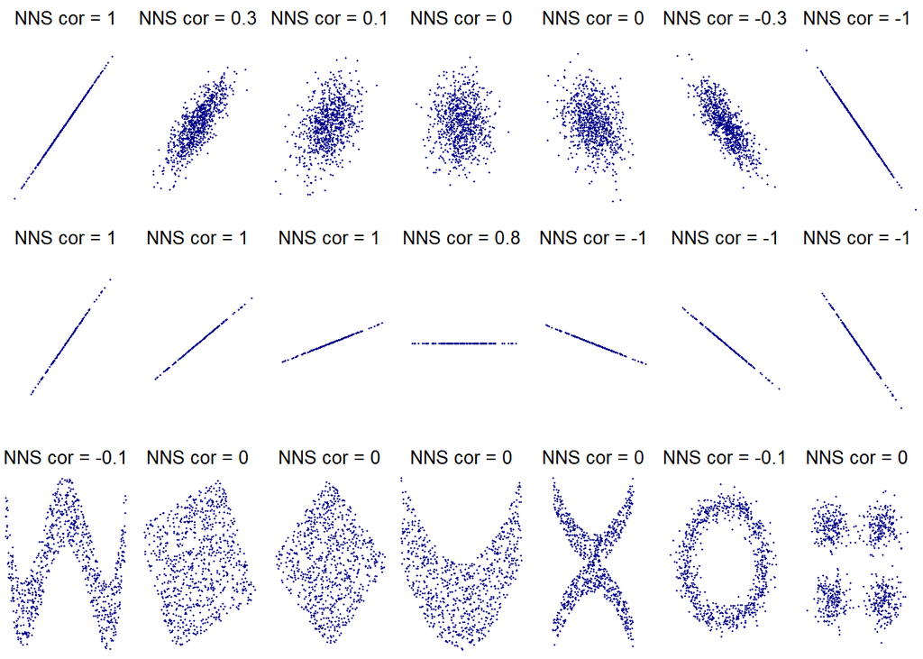

```r
output(metric = "NNScor")
```

# 4 References

- [Nonlinear Correlation and Dependence Using NNS](https://www.ssrn.com/abstract=3010414)
- [Wikipedia Commons Correlation Plots](https://en.wikipedia.org/wiki/File:Correlation_examples2.svg)
- [Using The Predictive Power Score in R](https://towardsdatascience.com/using-the-predictive-power-score-in-r-26c43d05dc01)